Fondamenti di Scienza dei Dati

10 luglio 2024

# Evoluzione del gioco nell'NBA dall'introduzione del tiro da 3 ad oggi

Luca Gasparotto

## Introduzione

[figure not shown]

La National Basketball Association (NBA) è la lega professionistica americana di pallacanestro di livello più alto.

È nella top 3 delle leghe sportive professionistiche per fatturato al mondo (10.58 miliardi di dollari). [^1]

[figure not shown]

Vi partecipano 30 squadre di cui 29 provenienti dagli USA e 1 dal Canada

[^1]: dati da sportbrief.com

### Perchè il basket:

- **1991**: inizio a praticare questo sport
- **1995**: mi appassiono alla Serie A e in seguito all'NBA
- **2024**: ancora in attività (circa)

### Perchè la NBA:

- Utilizzo della statistica intensivo
- Enorme mole di dati a disposizione
- È in continua evoluzione

### Oggetto dell'indagine:

Nel 1979 è stato introdotto nel regolamento del gioco il tiro da 3 punti.

> The three-point field goal area has parallel lines 3’ from the sidelines, extending from the baseline and an arc of 23’9” from the middle of the basket which intersects the parallel lines.

Conversione Piedi-Metri: 3' = 0.91m || 23'9' = 7.24m

Dagli angoli la distanza da canestro è pari a 22', ovvero circa 6.7m

(Nel resto del mondo si tira da 6.75m)

### Cosa cercheremo di capire:

- Quanto viene sfruttata come soluzione offensiva **rispetto al passato**?
- Giocare **in casa o in trasferta** ha un'influenza sull'utilizzo del tiro da tre?
- È cambiata la **distribuzione** dei tiri dal campo?
- È cambiato il **modo di giocare** delle squadre?
- Ha avuto effetti sui singoli **ruoli** dei giocatori?

## Dataset

### Provenienza:

- Reperibili su:
  - kaggle.com: [NBA Database](https://www.kaggle.com/datasets/wyattowalsh/basketball) e [NBA Stats 1947-present](https://www.kaggle.com/datasets/sumitrodatta/nba-aba-baa-stats)
  - github.com: DomSamangy/NBA_Shots_04_24
- Provengono da: [NBA.com](https://www.nba.com/?50)
- Formato: CSV

### Contenuto:

- Statistiche complete, base ed avanzate, dei giocatori per stagione
- Statistiche complete delle squadre (casa e trasferta) per singolo match e stagione
- Mappa dei tiri dal 2004 al 2024

### Dati scartati:

- Stagioni antecedenti al 1986 → dati sul tiro da 3 mancanti
- Stagione 2013 → presenti dati dei soli Playoffs

### Altro contenuto (non utilizzato):

- Play-by-play delle partite NBA dal '49 ad oggi
- Informazioni biografiche sui giocatori
- Informazioni sulle squadre, la loro storia e le città di appartenenza
- Informazioni sul draft NBA

## Evoluzione dell'approccio al tiro da 3 punti

### Utilizzo nel tempo

Proporzione tra media del numero di tiri da tre e la media di tutti i tiri dal campo per stagione

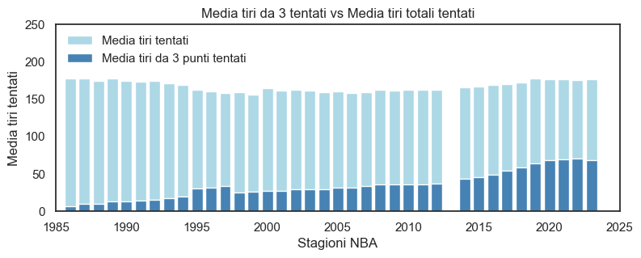

### Percentuale realizzativa nel tiro da 3 punti

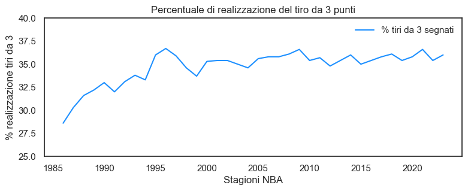

| Annata | % Segnati |
| --- | --- |
| 1986 | 28.6% |
| 1996 | 36.7% |
| 2023 | 36.0% |

| Periodo | Varianza |
| --- | --- |
| 1986-1996 | 3.4 |
| 1996-2023 | 0.4 |

La percentuale di successo è correlata all'aumento del numero di tentativi?

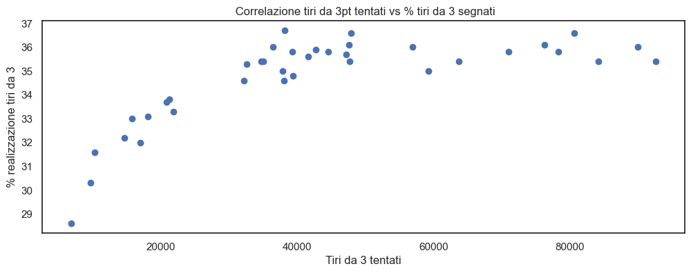

L'indice di correlazione di Pearson è pari a: 0.706  
Correlazione modesta e non lineare

L'aumento del tiro da 3 punti è avvenuto in seguito ad un aumento del ritmo di gioco o va a discapito del tiro da 2 punti?

**1) Numero possessi**

È aumentato il ritmo di gioco analizzando il numero dei possessi per stagione?

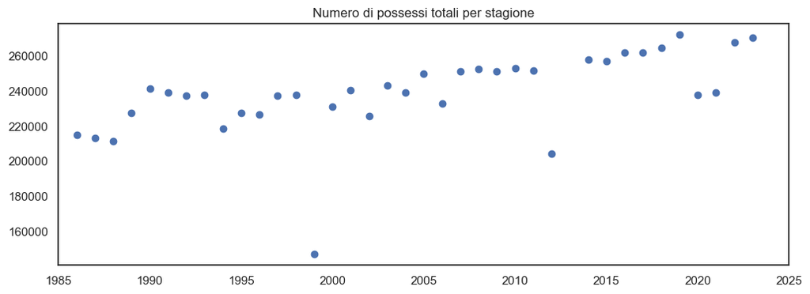

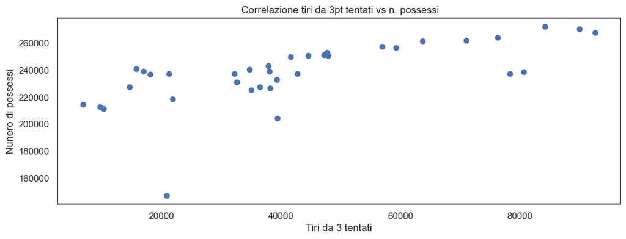

L'indice di correlazione di Pearson è pari a: 0.658  
Anche in questo caso correlazione modesta

**2) Tiro da 3 vs tiro da 2**

Osserviamo ora la proporzione tra tiri da 2 punti e tiri da 3 punti nei periodi 1986→1999 e 2000→2023:

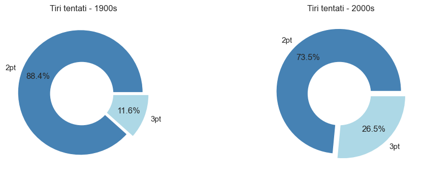

Match in cui la squadra in casa, quella in trasferta o entrambe hanno tentato più tiri da 3 punti che da 2:

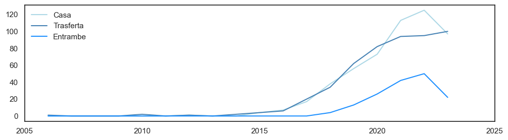

| Stagione | 2006 | 2007 | 2008 | 2009 | 2010 | 2011 | 2012 | 2013 | 2014 | 2015 | 2016 | 2017 | 2018 | 2019 | 2020 | 2021 | 2022 | 2023 |
| --- | --- | --- | --- | --- | --- | --- | --- | --- | --- | --- | --- | --- | --- | --- | --- | --- | --- | --- |
| Casa | 0 | 0 | 0 | 0 | 0 | 0 | 1 | 0 | 0 | 4 | 7 | 17 | 38 | 56 | 73 | 113 | 125 | 97 |
| Trasferta | 1 | 0 | 0 | 0 | 2 | 0 | 1 | 0 | 2 | 4 | 6 | 20 | 34 | 62 | 82 | 94 | 95 | 100 |
| Entrambe | 0 | 0 | 0 | 0 | 0 | 0 | 0 | 0 | 0 | 0 | 0 | 0 | 4 | 13 | 26 | 42 | 50 | 22 |

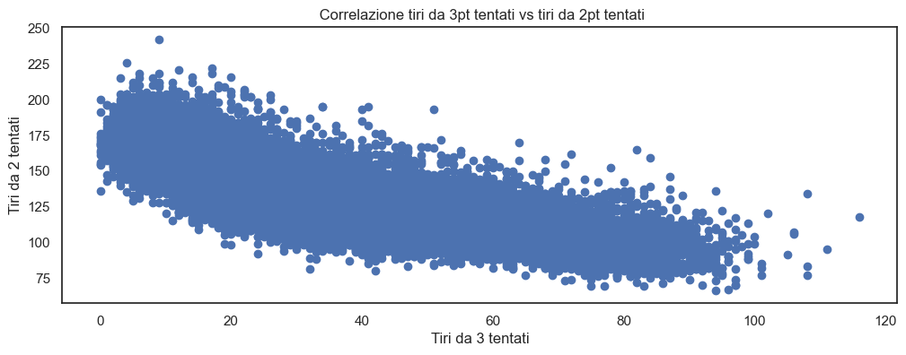

L'indice di correlazione di Pearson è pari a: -0.772  
Correlazione negativa modesta

## Casa vs Trasferta

C'è differenza tra giocare nel proprio palazzetto o in uno avversario?

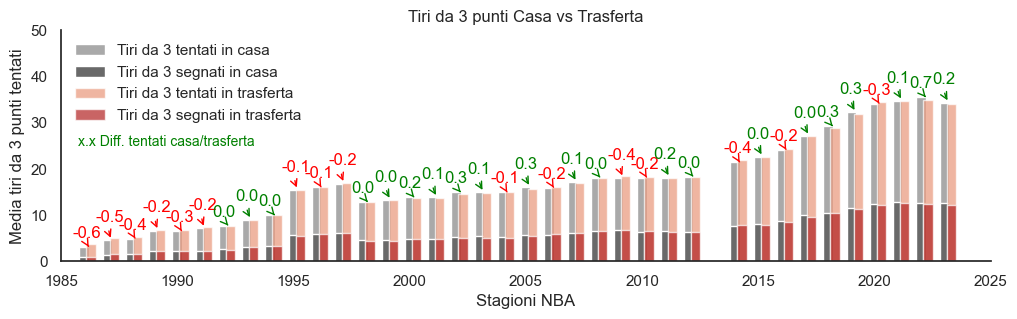

Tiri da 3 tentati in media, a partita:  
Casa: 17.314  
Trasferta: 17.354

### Casa vs Trasferta - Percentuale di realizzazione

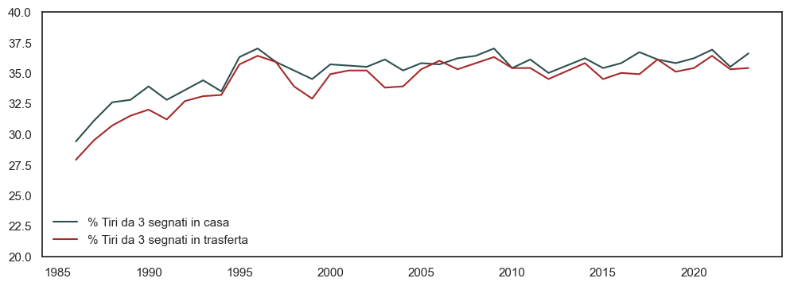

Mediamente la squadra di casa è più precisa nel tirare da 3 punti

## Distribuzione dei tiri sul campo

Identificazione zone di tiro dal campo nelle statistiche NBA:

- **Restricted Area**: la zona all'interno del semicerchio sotto canestro
- **In the paint**: l'area dei 3 secondi
- **Mid Range**: tiro dalla media distanza tra l'area dei 3 secondi e l'arco dei 3 punti
- **Corner 3s**: tiri da 3 punti dagli angoli
- **Above the Break 3s**: tiri da 3 punti dall'arco

[figure not shown]

### Distanza di tiro

Distribuzione delle distanze di tiro negli anni

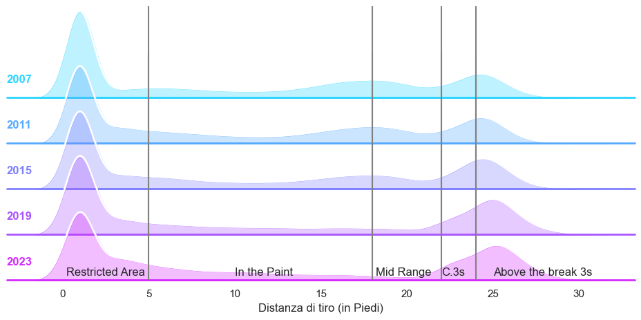

### Polarizzazione degli spot da cui si tira

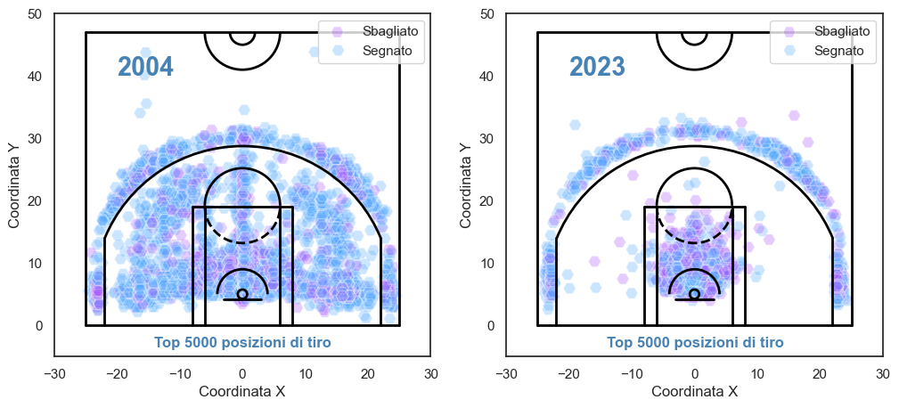

### Tiri ad alta percentuale

Tendenza a selezionare tiri ad alta percentuale o alta remunerazione

% di realizzazione per zona:

| Zona | %Realizzazione |
| --- | --- |
| Restricted Area | 61.6% |
| Mid Range | 39.9% |
| Long Two | 39.1% |
| Above the Break 3s | 35.1% |
| Corner 3s | 38.7% |

eFG% per i tiri da 3 punti:

| Zona | eFG% |
| --- | --- |
| Above the Break 3s | 52.7% |
| Corner 3s | 58.1% |

## Impatto sul gioco offensivo delle squadre

Necessaria una distinzione tra due tipologie di giocatori

1. Stelle o primi terminali offensivi
   - tendono ad avere di più la palla in mano
   - sono loro a finalizzare la maggior parte delle azioni offensive o a mettere i compagni in condizione di finalizzarle
   - spesso costruiscono autonomamente le proprie conclusioni a canestro
2. Gregari, specialisti o role-player
   - gestiscono meno palloni e solo in determinate situazioni
   - tendono a prendersi tiri a seguito di assist da parte dei compagni

**NB**: Assist → il passaggio precedente al tiro che permette e facilita la realizzazione di un canestro

Per introdurre questi aspetti nell'analisi dei dati viene calcolato un particolare indice e viene utilizzata una rilevazione statistica avanzata presente nei dataset considerati:

- **Player usage percentage**: stima la percentuale di possessi della squadra gestita dal singolo giocatore
- **Assisted/Unassisted Field Goal**: indica se il canestro è stato realizzato in seguito ad un assist o meno

### Mid-range shots

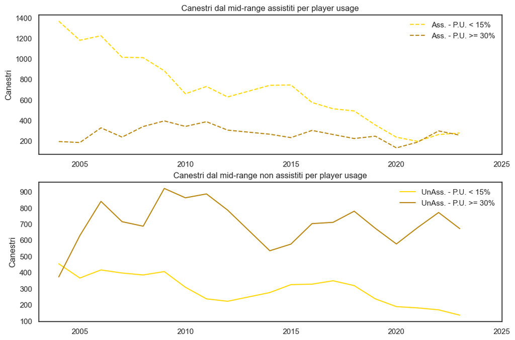

### 3 point shots

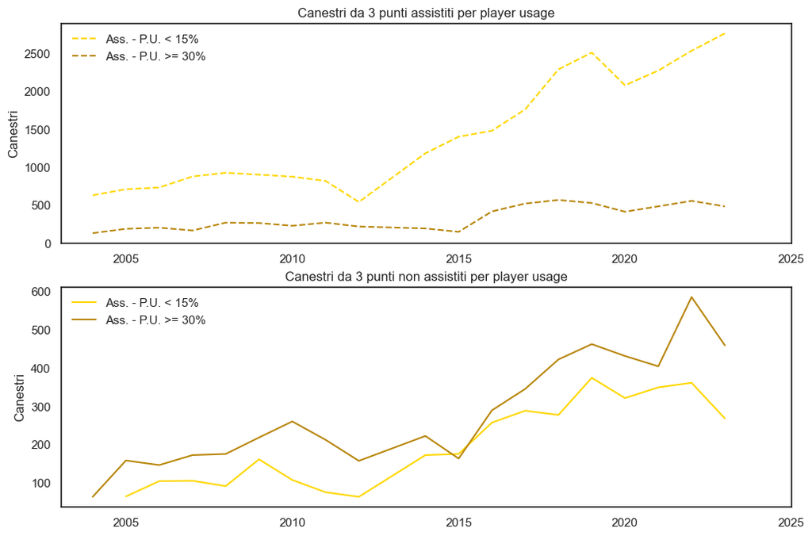

## Impatto sui ruoli

### Ruoli della pallacanestro

| Numero | Sigla | USA | Italia |
| --- | --- | --- | --- |
| 1 | PG | Point Guard | Playmaker |
| 2 | SG | Shooting Guard | Guardia |
| 3 | SF | Small Forward | Ala Piccola |
| 4 | PF | Power Forward | Ala Grande |
| 5 | C | Center | Centro/Pivot |

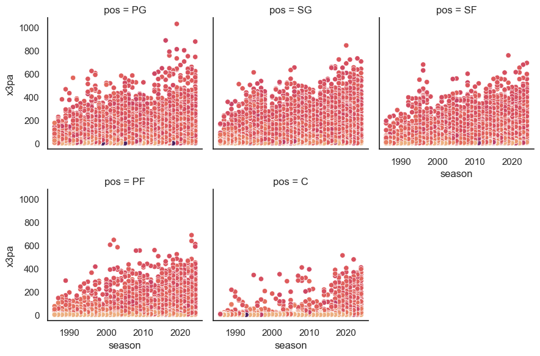

### Centri (Centers) - 5

Pivot, distanza di tiro < 30 piedi

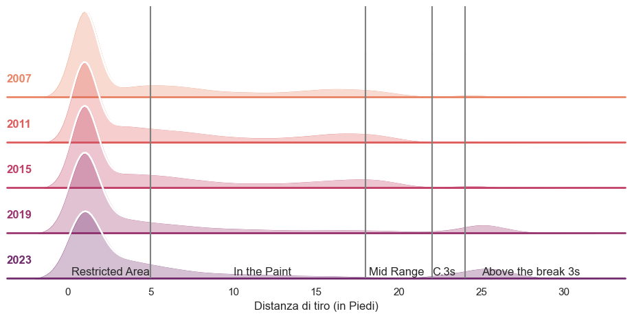

**Centri (Center)**:

- riduzione dei tiri dal limite dell'area
- aumento esponenziale dell'utilizzo del tiro da tre punti, anche da distanze notevoli

### Ali (Forwards)

Ali piccole e grandi, distanza di tiro < 30 piedi

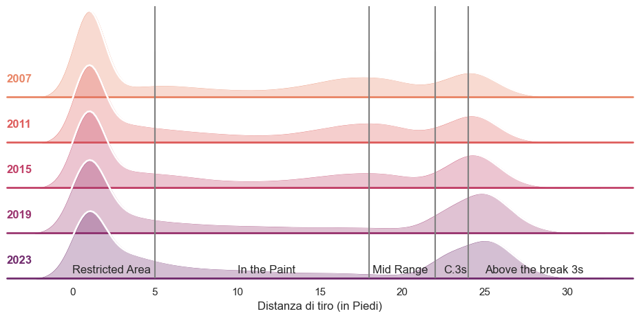

**Ali (Forward)**:

- aumentata la frequenza con cui tirano da tre
- nascita nuovi ruoli ibridi:
  - *Stretch-four*: in genere Power Forward (4) o Small Forward (3) con caratteristiche fisiche adatte, scopo: creare spazi in attacco
  - *Three-and-D*: Small Forward (3), (a volte anche Shooting Guards (2)), due caratteristiche principali: tiro da tre sugli scarichi e difesa 1-vs-1

### Guardie (Guards) - 1 e 2

Playmaker e guardie, tiri da distanza > 18 piedi e < 30 piedi

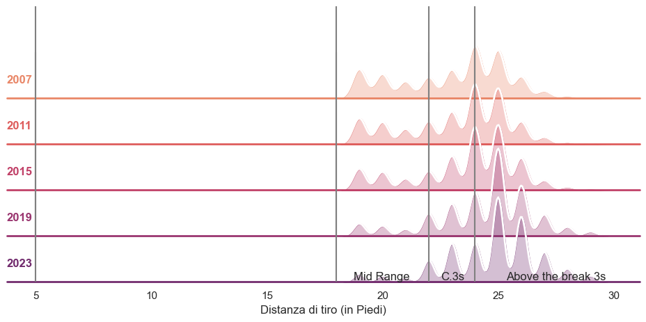

**Guardie (Guards)**:

- mantenuta la caratteristica di essere i principali tiratori da 3 punti
- aumentato progressivamente range di tiro, si osserva una certa frequenza anche da oltre 8 metri

## Conclusioni

- Sono aumentati i tiri da tre punti presi nel corso del tempo

↓

- Mediamente si tira lo stesso numero di tiri in casa e trasferta, ma in casa si è più precisi

↓

- Le squadre hanno ottimizzato il gioco offensivo andado a cercare tiri più efficienti per percentuale o remunerazione

↓

- I giocatori si sono adeguati modificando le caratteristiche tipiche dei loro ruoli per aderire al piano delle squadre di ricercare sempre la conclusione a canestro migliore